# Practical Machine Learning Project Report

Ananth

Thursday, December 18, 2014

### Executive Summary

The main objective of this project is to demonstrate the analysis and model building process of machine learning tools and techniques.

Using devices such as Jawbone Up, Nike FuelBand, and Fitbit it is now possible to collect a large amount of data about personal activity relatively inexpensively.

The exercises were performed by six male participants aged between 20-28 years, with little weight lifting experience. They made sure that all participants could easily simulate the mistakes in a safe and controlled manner by using a relatively light dumbbell (1.25kg)

One thing that people regularly do is quantify how much of a particular activity they do, but they rarely quantify how well they do it. In this project, the goal will be to use data from accelerometers on the belt, forearm, arm, and dumbell of 6 participants. They were asked to perform barbell lifts correctly and incorrectly in 5 different ways. they perform an exercise with a barbell using five techniques that range “perfect form” (A) to “very poor form” (E).

The question these researchers are exploring is whether machine learning techniques can be used on the data they collected to predict whether a person is using proper form in their exercise or not. The ultimate vision of the team is to provide real-time feedback to those performing exercises to improve the quality of their exercise experience.

### Data Sources

The training data for this project are available here:

https://d396qusza40orc.cloudfront.net/predmachlearn/pml-training.csv

The test data are available here:

https://d396qusza40orc.cloudfront.net/predmachlearn/pml-testing.csv

The data for this project come from this source: http://groupware.les.inf.puc-rio.br/har.

### Load required Libraries and set default Project directory

```r
library(caret)
library("randomForest")
library(gbm)
library(plyr)
setwd("C:/Users/admin/Desktop/Coursera/Practical Machine Learning/Project")
```

### Load Training and Testing Dataset

```r
training <- read.csv("pml-training.csv", row.names = 1)
testing <- read.csv("pml-testing.csv", row.names = 1)

dim(training)
```

```
## [1] 19622   159
```

```r
dim(testing)
```

```
## [1]  20 159
```

The project source data consists of two data sets. “pml-training.csv”" contains 19622 observations with 159 variables. “pml-testing.csv”" contains 20 observations and 159 variables.

### Data Cleansing and Preparation

Remove near zero covariates and those with more than 80% missing values since these variables will not provide much power for prediction.

```r
# remove near zero covariates
zerovar <- nearZeroVar(training, saveMetrics = T)
training <- training[, !zerovar$nzv]

# remove variables with more than 80% missing values
mval <- sapply(colnames(training), function(x) if(sum(is.na(training[, x])) > 0.8*nrow(training)){return(T)}else{return(F)})
training <- training[, !mval]
```

### Model Development

1. Calculate correlations between each remaining feature to the response, “classe”. Use spearman rank based correlation because classe is a factor.
2. Plot the two features that have highest correlation with “classe”" and color with classe to see if we can separate response based on these features.

```r
# calculate correlations
cor <- abs(sapply(colnames(training[, -ncol(training)]), function(x) cor(as.numeric(training[, x]), as.numeric(training$classe), method = "spearman")))
summary(cor)
```

```
##     Min.  1st Qu.   Median     Mean  3rd Qu.     Max.
## 0.001525 0.014720 0.052370 0.086210 0.137400 0.317300
```

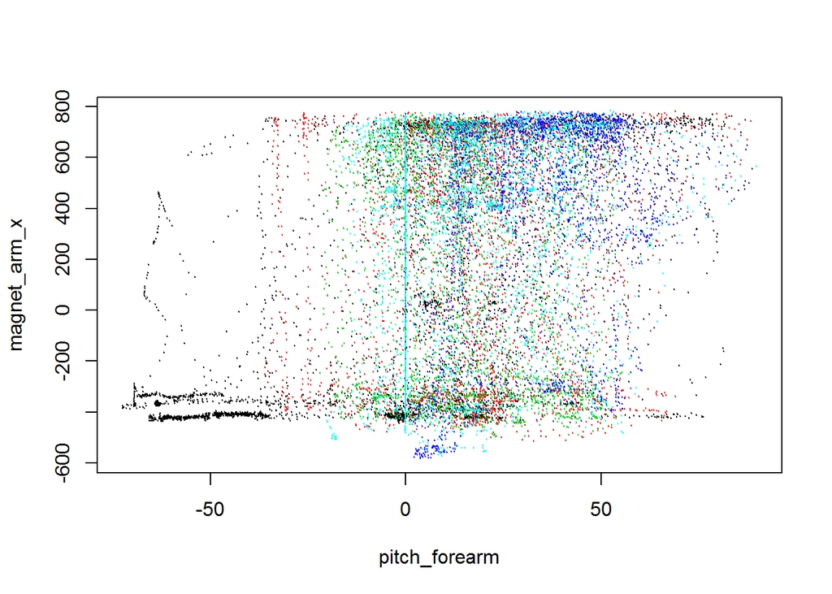

```r
#plot predictors

plot(training[, names(which.max(cor))], training[, names(which.max(cor[-which.max(cor)]))], col = training$classe, pch = 19, cex = 0.1, xlab = names(which.max(cor)), ylab = names(which.max(cor[-which.max(cor)])))
```

It appears like no strong predictors that correlates with “classe” well, so linear regression model is probably not suitable in this case. Boosting and random forests algorithms may generate more robust predictions for our data.

### Boosting model

Fit model with boosting algorithm and 10-fold cross validation to predict “classe” with all other predictors.

Plot accuracy of this model on the scale [0.9, 1].

```r
set.seed(456)
boostFit <- train(classe ~ ., method = "gbm", data = training, verbose = F, trControl = trainControl(method = "cv", number = 10))
boostFit
```

```
## Stochastic Gradient Boosting
##
## 19622 samples
##    57 predictor
##     5 classes: 'A', 'B', 'C', 'D', 'E'
##
## No pre-processing
## Resampling: Cross-Validated (10 fold)
##
## Summary of sample sizes: 17658, 17659, 17662, 17660, 17659, 17660, ...
##
## Resampling results across tuning parameters:
##
##   interaction.depth  n.trees  Accuracy   Kappa      Accuracy SD
##   1                   50      0.8402295  0.7971945  0.007864401
##   1                  100      0.9017937  0.8756424  0.003856919
##   1                  150      0.9270709  0.9076103  0.003935372
##   2                   50      0.9582085  0.9470917  0.006687132
##   2                  100      0.9866985  0.9831751  0.001943801
##   2                  150      0.9927125  0.9907820  0.001731906
##   3                   50      0.9846601  0.9805960  0.001972322
##   3                  100      0.9934769  0.9917491  0.001745092
##   3                  150      0.9967894  0.9959391  0.001225884
##   Kappa SD
##   0.009985704
##   0.004893264
##   0.005002358
##   0.008476947
##   0.002457498
##   0.002191417
##   0.002494039
##   0.002207773
##   0.001550534
##
## Tuning parameter 'shrinkage' was held constant at a value of 0.1
## Accuracy was used to select the optimal model using  the largest value.
## The final values used for the model were n.trees = 150,
##  interaction.depth = 3 and shrinkage = 0.1.
```

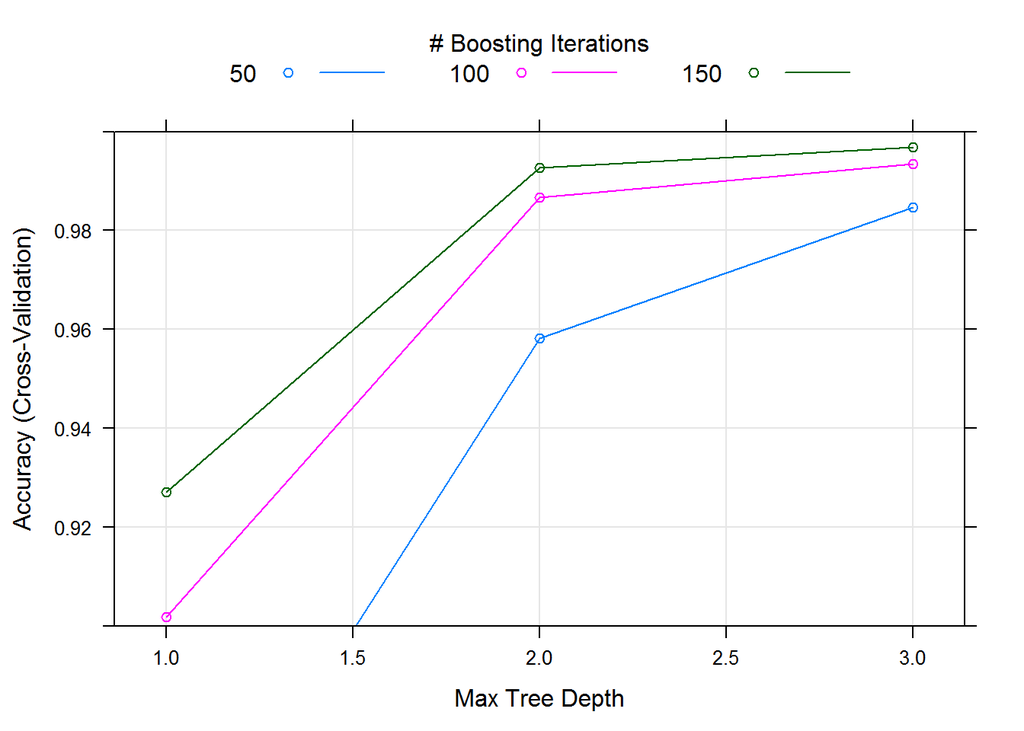

```r
plot(boostFit, ylim = c(0.9, 1))
```

The boosting algorithm generated a good model with accuracy = 0.997.

### Random forests model

Fit model with random forests algorithm and 10-fold cross validation to predict classe with all other predictors. Plot accuracy of the model on the same scale as boosting model.

```r
set.seed(456)
rfFit <- train(classe ~ ., method = "rf", data = training, importance = T, trControl = trainControl(method = "cv", number = 10))
rfFit
```

```
## Random Forest
##
## 19622 samples
##    57 predictor
##     5 classes: 'A', 'B', 'C', 'D', 'E'
##
## No pre-processing
## Resampling: Cross-Validated (10 fold)
##
## Summary of sample sizes: 17658, 17659, 17662, 17660, 17659, 17660, ...
##
## Resampling results across tuning parameters:
##
##   mtry  Accuracy   Kappa      Accuracy SD   Kappa SD
##    2    0.9922024  0.9901353  0.0026548414  0.0033594642
##   40    0.9995922  0.9994842  0.0004684367  0.0005925156
##   79    0.9989805  0.9987105  0.0007600442  0.0009613407
##
## Accuracy was used to select the optimal model using  the largest value.
## The final value used for the model was mtry = 40.
```

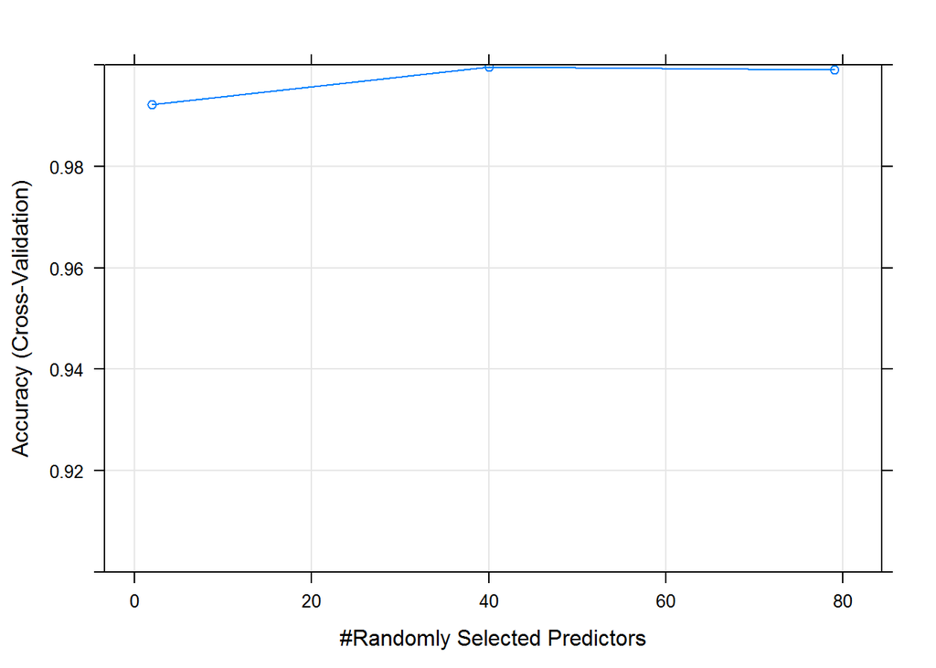

```r
plot(rfFit, ylim = c(0.9, 1))
```

```r
imp <- varImp(rfFit)$importance
imp$max <- apply(imp, 1, max)
imp <- imp[order(imp$max, decreasing = T), ]
```

The random forests algorithm generated a very accurate model with accuracy close to 1. Compared to boosting model, this model generally has better performance in terms of accuracy as we see from the plots.

### Final model and prediction

When we Compare the model accuracy of the two models generated, random forests and boosting, random forests model has overall better accuracy.

Predict the test set and output results for automatic grader.

```r
# final model
rfFit$finalModel
```

```
##
## Call:
##  randomForest(x = x, y = y, mtry = param$mtry, importance = ..1)
##                Type of random forest: classification
##                      Number of trees: 500
## No. of variables tried at each split: 40
##
##         OOB estimate of  error rate: 0.03%
## Confusion matrix:
##      A    B    C    D    E  class.error
## A 5580    0    0    0    0 0.0000000000
## B    1 3796    0    0    0 0.0002633658
## C    0    3 3419    0    0 0.0008766803
## D    0    0    1 3214    1 0.0006218905
## E    0    0    0    0 3607 0.0000000000
```

```r
# prediction
(prediction <- as.character(predict(rfFit, testing)))
```

```
##  [1] "B" "A" "B" "A" "A" "E" "D" "B" "A" "A" "B" "C" "B" "A" "E" "E" "A"
## [18] "B" "B" "B"
```

### Generate Files

```r
# code from Prediction Assignment Submission: Instructions
pml_write_files = function(x){
  n = length(x)
  for(i in 1:n){
    filename = paste0("./problem_id_", i, ".txt")
    write.table(x[i], file = filename, quote = FALSE, row.names = FALSE, col.names = FALSE)
  }
}
pml_write_files(prediction)
```